# 7월 1일 시험

황 성 윤

2019 7 1

## Q1 다음의 값을 R 내장함수를 이용하여 구하시오.

### 1) 시행횟수가 6이고 성공확률이 1/3인 이항분포에서 성공횟수가 3이 될 확률

```r
dbinom(3,size=6,prob=1/3)
```

```
## [1] 0.2194787
```

정답 : 약 0.2195 ### 2) 평균이 170이고 표준편차가 6인 정규분포에서 상위 20%인 사람들의 키 범위

```r
qnorm(0.8,mean=170,sd=6)
```

```
## [1] 175.0497
```

정답 : 약 175.05 이상 ### 3) 자유도가 3인 카이제곱분포에서 누적확률이 95%일 때의 값

```r
qchisq(0.95,df=3)
```

```
## [1] 7.814728
```

정답 : 약 7.8147 ### 4) 자유도가 2인 t분포에서 누적확률이 0.975일 때의 값

```r
qt(0.975,df=2)
```

```
## [1] 4.302653
```

정답 : 약 4.303 ### 5) 표준정규분포에서 확률변수의 값이 1일 때의 누적확률

```r
pnorm(1,mean=0,sd=1)
```

```
## [1] 0.8413447
```

정답 : 약 0.8413

## 2. 다음의 문항이 베르누이 시행인지 판단하시오.

### 1) 영화관에서 줄을 기다리는 시간 -> no

### 2) 전화가 왔을 때, 전화를 한 사람이 여자인지 측정 -> yes

### 3) 주사위를 한 번 던졌을 때, 나오는 숫자 체크 -> no

### 4) 동전의 앞면이 위로 향하고 있는지 체크 -> yes

### 5) 사람의 눈이 녹색인지 체크 -> no

## 3. R 내장 데이터 iris를 이용하여 setosa 종 Sepal.Length의 모평균에 대한 95% 신뢰구간을 구하시오.

```r
iris <- iris
library(dplyr)
setosa <- iris %>%
  filter(Species=="setosa")
setosa$Sepal.Length
```

```
##  [1] 5.1 4.9 4.7 4.6 5.0 5.4 4.6 5.0 4.4 4.9 5.4 4.8 4.8 4.3 5.8 5.7 5.4
## [18] 5.1 5.7 5.1 5.4 5.1 4.6 5.1 4.8 5.0 5.0 5.2 5.2 4.7 4.8 5.4 5.2 5.5
## [35] 4.9 5.0 5.5 4.9 4.4 5.1 5.0 4.5 4.4 5.0 5.1 4.8 5.1 4.6 5.3 5.0
```

```r
shapiro.test(setosa$Sepal.Length)
```

```
##
##  Shapiro-Wilk normality test
##
## data:  setosa$Sepal.Length
## W = 0.9777, p-value = 0.4595
```

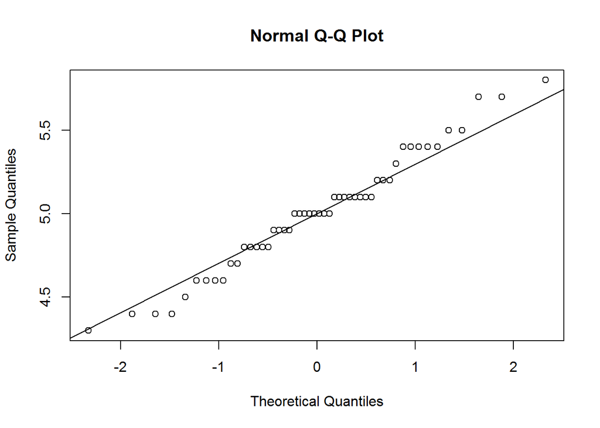

```r
qqnorm(setosa$Sepal.Length) ; qqline(setosa$Sepal.Length)
```

정규성 검정 결과 p-value의 값이 0.4595로 유의수준 0.05보다 크다. 따라서 setosa 종 Sepal.Length는 정규분포를 따른다고 볼 수 있다. 이에 따라 모평균에 대한 95% 신뢰구간을 구하면 다음과 같다.

```r
(x.bar <- mean(setosa$Sepal.Length))
```

```
## [1] 5.006
```

```r
(sd.bar <- sd(setosa$Sepal.Length))
```

```
## [1] 0.3524897
```

```r
(alpha <- 0.05)
```

```
## [1] 0.05
```

```r
(z <- qnorm(1-(alpha/2)))
```

```
## [1] 1.959964
```

```r
(n <- length(setosa$Sepal.Length))
```

```
## [1] 50
```

```r
ll <- x.bar-z*sd.bar/sqrt(n)
ul <- x.bar+z*sd.bar/sqrt(n)
(c.l <- c(ll,ul))
```

```
## [1] 4.908297 5.103703
```

정답 : 약 4.908 ~ 약 5.104

## 4. 한 농구선수가 자유투를 던지면 10번 중 7번을 성공한다고 할 때, 다음 물음에 답하시오.

### 1) 자유투를 10번 던져서 9번 이상 성공할 확률

성공한 자유투 수를 X라 하면 X ~ B(10,0.7) 이다.

```r
1-pbinom(8,size=10,prob=0.7)
```

```
## [1] 0.1493083
```

정답 : 약 0.1493 ### 2) 자유투를 10번 던져서 5번 이상 8번 이하로 성공할 확률

```r
pbinom(8,size=10,prob=0.7)-pbinom(4,size=10,prob=0.7)
```

```
## [1] 0.8033427
```

정답 : 약 0.8033

## 5. 2006년 조사에 의하면 한국인의 1인 1일 평균 알코올 섭취량은 8.1g이다. 2008년 무작위로 뽑은 알코올 섭취량이 다음과 같을 때 평균 알코올 섭취량이 달라졌는지 검정하시오.

## 16.90,13.21,15.67,9.87,13.15,9.98,3.56,14.50,8.12,6.97

Hypothesis  
H0 : mu==8.1 v.s H1 : mu!=8.1 우선 데이터를 생성하고 정규성을 검정해본다.

```r
alcohol <- c(16.90,13.21,15.67,9.87,13.15,9.98,3.56,14.50,8.12,6.97)
shapiro.test(alcohol)
```

```
##
##  Shapiro-Wilk normality test
##
## data:  alcohol
## W = 0.96287, p-value = 0.818
```

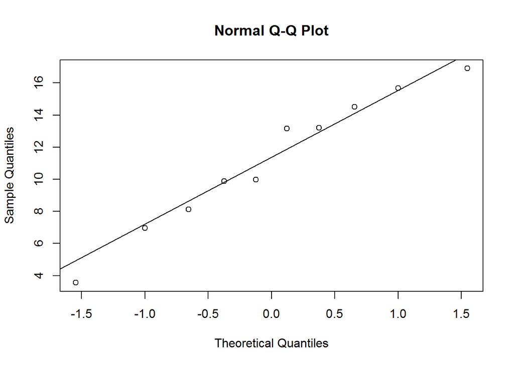

```r
qqnorm(alcohol) ; qqline(alcohol)
```

검정결과, p-value의 값이 0.818로 유의수준 0.05보다 크다. 따라서 알코올 섭취량을 정규분포를 따른다고 볼 수 있다. 또한 표본크기 30 미만의 소표본이므로 one-sample T-Test를 수행하면 다음과 같다.

```r
t.test(alcohol,mu=8.1)
```

```
##
##  One Sample t-test
##
## data:  alcohol
## t = 2.3182, df = 9, p-value = 0.04562
## alternative hypothesis: true mean is not equal to 8.1
## 95 percent confidence interval:
##   8.174819 14.211181
## sample estimates:
## mean of x
##    11.193
```

검정결과, p-value의 값이 약 0.0456으로 유의수준 0.05보다 작다. 따라서 귀무가설을 기각하게 되고, 이에 따라 평균 알코올 섭취량이 달라졌다고 볼 수 있다.

## 6. 정규분포에서 from <= X <= to 의 확률을 구하는 함수 rangenorm(from,to,mean,sd)을 작성하고 rangenorm(-1.96,1.96,0,1)을 구하시오.

```r
rangenorm <- function(from,to,mean,sd) {
  prob <- pnorm(to,mean,sd)-pnorm(from,mean,sd)
  return(prob)
}
rangenorm(-1.96,1.96,0,1)
```

```
## [1] 0.9500042
```

## 7. mpg 데이터셋에서 다음을 검정해보시오.

### 1) subcompact 자동차와 midsize 자동차의 도시연비

데이터 전처리

```r
library(ggplot2)
require(dplyr)
mpg <- mpg
mpg1 <- mpg %>%
  filter(class %in% c("subcompact","midsize"))
mpg1$cty[mpg1$class=="subcompact"]
```

```
##  [1] 18 18 17 16 15 15 15 15 14 28 24 25 23 24 26 25 24 21 19 19 20 20 17
## [24] 16 17 21 19 19 19 35 29 21 19 20 20
```

```r
mpg1$cty[mpg1$class=="midsize"]
```

```
##  [1] 15 17 16 19 22 18 18 17 18 18 21 21 18 18 19 23 23 19 19 18 19 19 18
## [24] 16 17 18 16 21 21 21 21 18 18 19 21 18 19 21 16 18 17
```

Group1 : class==“subcompact” / Group2 : class==“midsize”  
Hypothesis  
H0 : mu1==mu2 v.s H1 : mu1!=mu2  
우선, 각 집단에 대한 도시 연비(cty)가 정규성을 나타내는지 검정해본다.

```r
shapiro.test(mpg1$cty[mpg1$class=="subcompact"])
```

```
##
##  Shapiro-Wilk normality test
##
## data:  mpg1$cty[mpg1$class == "subcompact"]
## W = 0.91723, p-value = 0.01187
```

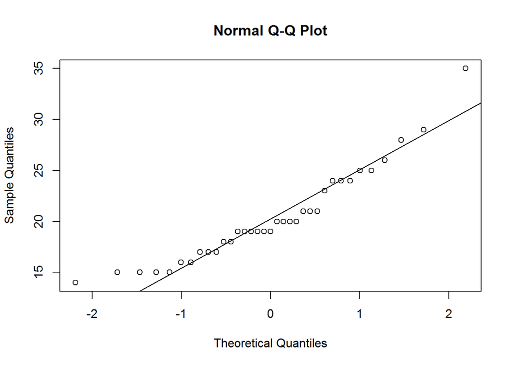

```r
qqnorm(mpg1$cty[mpg1$class=="subcompact"]) ; qqline(mpg1$cty[mpg1$class=="subcompact"])
```

```r
shapiro.test(mpg1$cty[mpg1$class=="midsize"])
```

```
##
##  Shapiro-Wilk normality test
##
## data:  mpg1$cty[mpg1$class == "midsize"]
## W = 0.93251, p-value = 0.01751
```

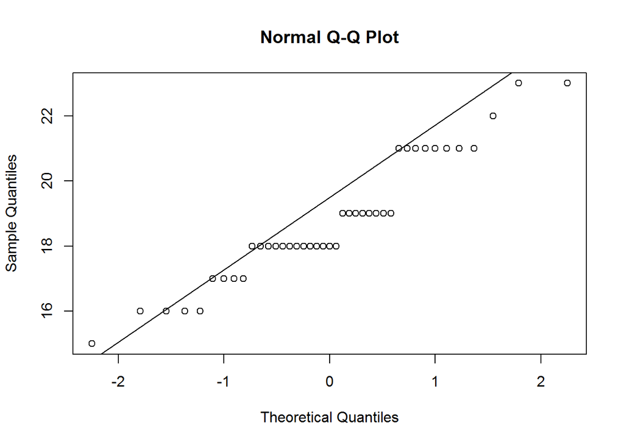

```r
qqnorm(mpg1$cty[mpg1$class=="midsize"]) ; qqline(mpg1$cty[mpg1$class=="midsize"])
```

```r
wilcox.test(mpg1$cty~mpg1$class)
```

```
##
##  Wilcoxon rank sum test with continuity correction
##
## data:  mpg1$cty by mpg1$class
## W = 588, p-value = 0.1748
## alternative hypothesis: true location shift is not equal to 0
```

검정결과, p-value의 값이 0.1748이고 이는 유의수준 0.05보다 크다. 따라서 귀무가설을 기각하지 못하고, 이에 따라 subcompact 자동차와 midsize 자동차의 도시 연비는 차이가 없다고 결론내린다.  
만약, 두 집단의 도시 연비가 모두 정규분포를 따른다는 가정이 주어졌다고 해보자. 이때는 우선 두 집단의 등분산성을 검정(F-test)해본다.  
Hypothesis  
H0 : sigma1==sigma2 v.s H1 : sigma1!=sigma2

```r
var.test(mpg1$cty~mpg1$class)
```

```
##
##  F test to compare two variances
##
## data:  mpg1$cty by mpg1$class
## F = 0.17888, num df = 40, denom df = 34, p-value = 5.201e-07
## alternative hypothesis: true ratio of variances is not equal to 1
## 95 percent confidence interval:
##  0.09194321 0.34194788
## sample estimates:
## ratio of variances
##          0.1788836
```

검정결과, p-value의 값이 매우 작은 값이다. 따라서 두 집단의 분산이 같다고 볼 수 없고, 이에 따라 이분산을 가정한 Welch’s two-sample T-Test를 실시한다.

```r
t.test(mpg1$cty~mpg1$class,var.equal=F)
```

```
##
##  Welch Two Sample t-test
##
## data:  mpg1$cty by mpg1$class
## t = -1.934, df = 44.299, p-value = 0.05952
## alternative hypothesis: true difference in means is not equal to 0
## 95 percent confidence interval:
##  -3.29829641  0.06763439
## sample estimates:
##    mean in group midsize mean in group subcompact
##                 18.75610                 20.37143
```

검정결과, p-value의 값이 약 0.059이고 이는 유의수준 0.05보다 크다. 따라서 귀무가설을 기각하지 못하고, 이에 따라 subcompact 자동차와 midsize 자동차의 도시 연비는 차이가 없다고 결론내린다.

### 2) 일반 휘발유(r)와 고급 휘발유(p)의 고속도로 연비

데이터 전처리

```r
library(ggplot2)
require(dplyr)
mpg2 <- mpg %>%
  filter(fl %in% c("r","p"))
mpg2$hwy[mpg1$fl=="r"]
```

```
##   [1] 30 26 26 27 26 25 28 27 25 25 25 25 24 23 20 20 17 26 23 24 19 15 27
##  [24] 30 26 29 26 24 24 22 22 24 24 22 21 19 18 17 19 17 17 17 17 16 18 15
##  [47] 16 17 17 16 15 15 17 17 18 17 15 17 26 25 26 24 21 22 23 22 20 33 32
##  [70] 29 32 36 29 26 31 26 26 28 26 29 28 27 24 24 24 19 20 17 19 18 18 18
##  [93] 17 18 17 19 17 29 27 31 32 27 26 26 25 25 20 18 26 26 26 26 26 25 27
## [116] 25 27 20 20 19 17 20 17 27 31 31 26 28 27 31 26 26 27 30 33 35 37 35
## [139] 15 18 20 20 22 17 19 29 26 29 29 26 29 29 29 23 24 29 26 28 29 29 29
## [162] 26 26 26
```

```r
mpg2$hwy[mpg1$fl=="p"]
```

```
##  [1] 29 29 31 25 17 25 23 23 17 19 15 17 19 17 19 19 17 17 17 16 16 32 34
## [24] 30 14 15 15 16 19 27 28 25 25 24 27 25 26 23 26 29 26 31 18 20 29 24
## [47] 29
```

Group1 : fl==“r” / Group2 : fl==“p”  
Hypothesis  
H0 : mu1==mu2 v.s H1 : mu1!=mu2  
우선, 각 집단에 대한 고속도로 연비(hwy)가 정규성을 나타내는지 검정해본다.

```r
shapiro.test(mpg2$hwy[mpg1$fl=="r"])
```

```
##
##  Shapiro-Wilk normality test
##
## data:  mpg2$hwy[mpg1$fl == "r"]
## W = 0.9561, p-value = 5.03e-05
```

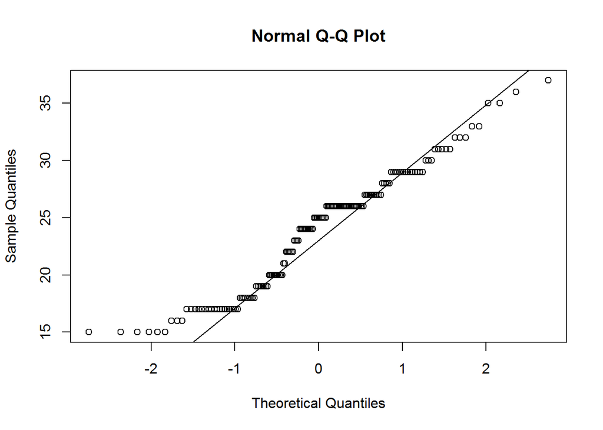

```r
qqnorm(mpg2$hwy[mpg1$fl=="r"]) ; qqline(mpg2$hwy[mpg1$fl=="r"])
```

```r
shapiro.test(mpg2$hwy[mpg1$fl=="p"])
```

```
##
##  Shapiro-Wilk normality test
##
## data:  mpg2$hwy[mpg1$fl == "p"]
## W = 0.93217, p-value = 0.009094
```

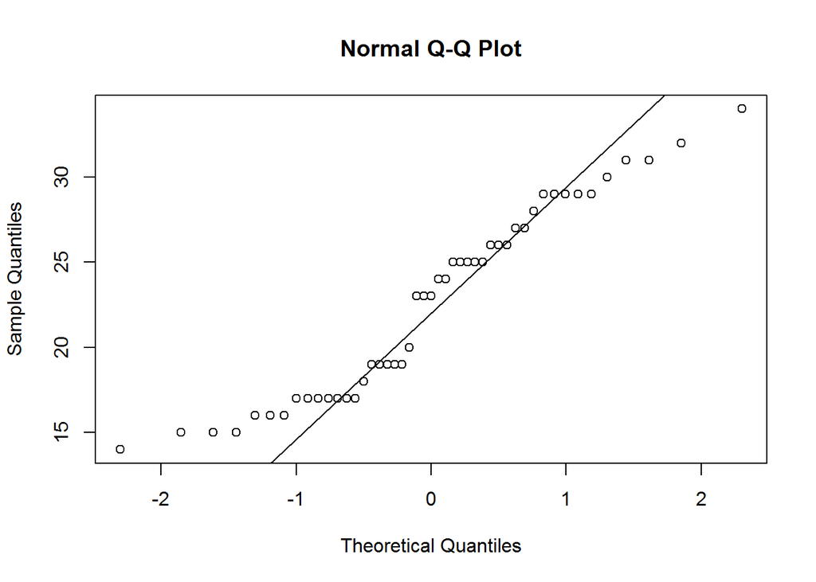

```r
qqnorm(mpg2$hwy[mpg1$fl=="p"]) ; qqline(mpg2$hwy[mpg1$fl=="p"])
```

검정결과, 두 집단 모두 p-value의 값이 유의수준 0.05보다 작다. 따라서 정규분포를 따른다고 볼 수 없으므로 관측치의 순위와 부호를 이용하는 비모수 검정인 Wilcoxon rank sum test를 실시한다.

```r
wilcox.test(mpg2$hwy~mpg2$fl)
```

```
##
##  Wilcoxon rank sum test with continuity correction
##
## data:  mpg2$hwy by mpg2$fl
## W = 5420, p-value = 0.008495
## alternative hypothesis: true location shift is not equal to 0
```

```r
var.test(mpg2$hwy~mpg2$fl)
```

```
##
##  F test to compare two variances
##
## data:  mpg2$hwy by mpg2$fl
## F = 0.51064, num df = 51, denom df = 167, p-value = 0.006139
## alternative hypothesis: true ratio of variances is not equal to 1
## 95 percent confidence interval:
##  0.3353372 0.8204816
## sample estimates:
## ratio of variances
##          0.5106396
```

검정결과, p-value의 값이 매우 작은 값이다. 따라서 두 집단의 분산이 같다고 볼 수 없고, 이에 따라 이분산을 가정한 Welch’s two-sample T-Test를 실시한다.

```r
t.test(mpg2$hwy~mpg2$fl,var.equal=F)
```

```
##
##  Welch Two Sample t-test
##
## data:  mpg2$hwy by mpg2$fl
## t = 3.2352, df = 118.29, p-value = 0.001576
## alternative hypothesis: true difference in means is not equal to 0
## 95 percent confidence interval:
##  0.8676632 3.6057800
## sample estimates:
## mean in group p mean in group r
##        25.23077        22.99405
```

## 8. 멘델의 유전법칙을 확인하기 위해 실험을 통해 완두콩의 형질을 확인한 결과 둥글고 황색, 둥글고 녹색, 주름지고 황색, 주름지고 녹색 순으로 322, 109, 99, 29 개가 나타났다. 이 결과가 멘델의 법칙 비율인 9:3:3:1 에 맞는지 검정하시오.

Hypothesis  
H0 : p1=9/16, p2=3/16, p3=3/16, p4=1/16 v.s H1 : not H0

```r
mendel <- c(322,109,99,29)
chisq.test(mendel,p=c(9,3,3,1)/16)
```

```
##
##  Chi-squared test for given probabilities
##
## data:  mendel
## X-squared = 1.6806, df = 3, p-value = 0.6413
```

검정결과, p-value의 값이 0.6413이고 이는 유의수준 0.05보다 크다. 따라서 귀무가설을 기각하지 못하고, 이에 따라 실험결과는 멘델의 법칙을 따른다고 결론내린다.

## 9. R 내장 데이터인 “women”을 이용하여 다음을 구하시오.

## 키(height)와 몸무게(weight)의 곡선회귀분석을 통한 2차 회귀식

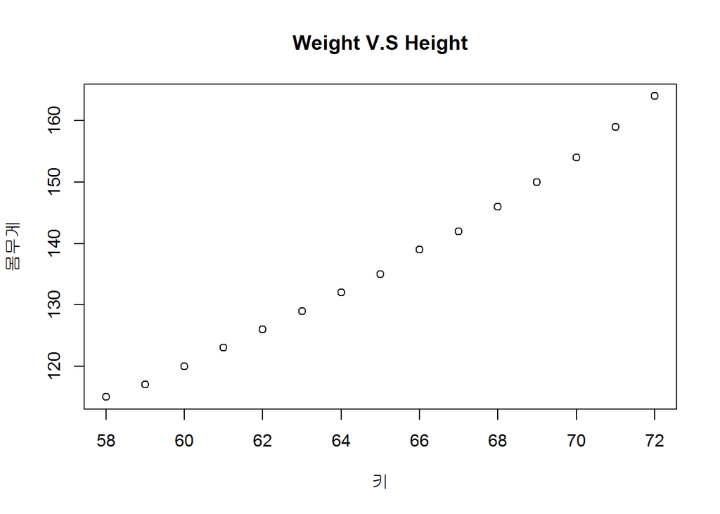

```r
women <- women
plot(x=women$height,y=women$weight,xlab="키",ylab="몸무게",main="Weight V.S Height")
```

```r
cor.test(women$weight,women$height)
```

```
##
##  Pearson's product-moment correlation
##
## data:  women$weight and women$height
## t = 37.855, df = 13, p-value = 1.091e-14
## alternative hypothesis: true correlation is not equal to 0
## 95 percent confidence interval:
##  0.9860970 0.9985447
## sample estimates:
##       cor
## 0.9954948
```

### 1) Simple regression model

```r
(fit1 <- lm(weight~height,data=women))
```

```
##
## Call:
## lm(formula = weight ~ height, data = women)
##
## Coefficients:
## (Intercept)       height
##      -87.52         3.45
```

```r
summary(fit1)
```

```
##
## Call:
## lm(formula = weight ~ height, data = women)
##
## Residuals:
##     Min      1Q  Median      3Q     Max
## -1.7333 -1.1333 -0.3833  0.7417  3.1167
##
## Coefficients:
##              Estimate Std. Error t value Pr(>|t|)
## (Intercept) -87.51667    5.93694  -14.74 1.71e-09 ***
## height        3.45000    0.09114   37.85 1.09e-14 ***
## ---
## Signif. codes:  0 '***' 0.001 '**' 0.01 '*' 0.05 '.' 0.1 ' ' 1
##
## Residual standard error: 1.525 on 13 degrees of freedom
## Multiple R-squared:  0.991,  Adjusted R-squared:  0.9903
## F-statistic:  1433 on 1 and 13 DF,  p-value: 1.091e-14
```

ANOVA table에 따르면 키는 몸무게에 유의한 영향을 미치고 있다고 보여진다. 그렇다면 fit1이 기본가정인 등분산성, 정규성, 선형성, 독립성을 만족하고 있는지 확인해보자.

### 2) Checking assumptions

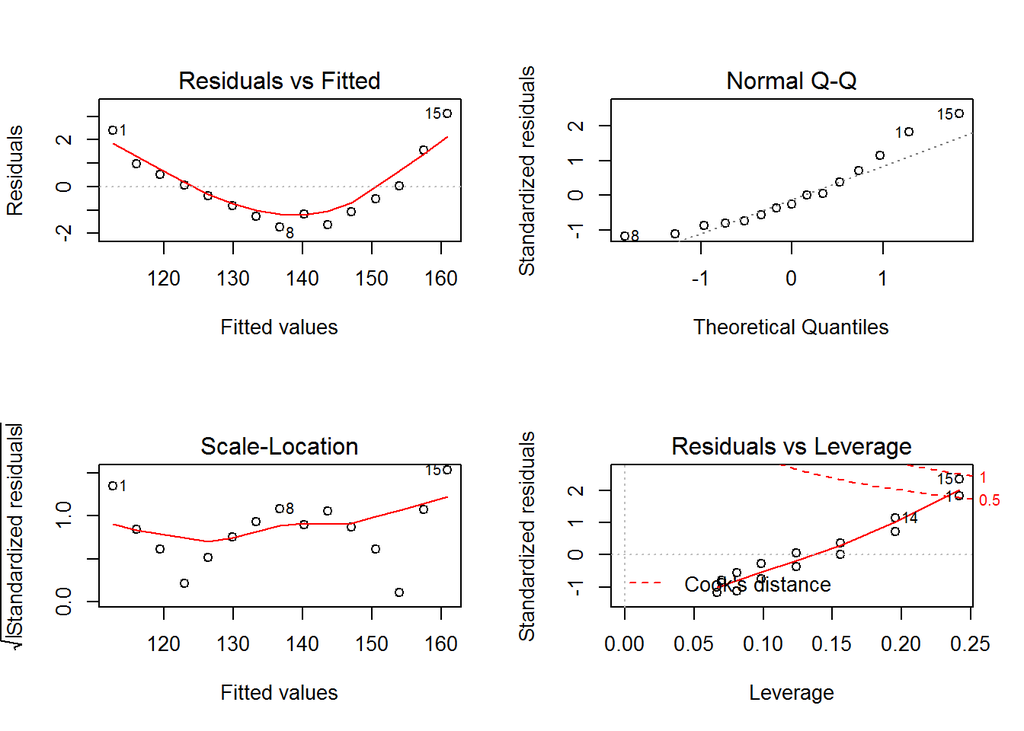

```r
par(mfrow=c(2,2))
plot(fit1)
```

```r
par(mfrow=c(1,1))
```

위의 4가지 그래프에 의하면, 이상치가 존재하고 선형성, 등분산성, 독립성이 의심가는 상황이다.

#### 1)) 정규성

먼저 잔차에 대한 정규성을 Shapiro-Wilk 검정법을 통해 실시해본다.

```r
shapiro.test(fit1$residuals)
```

```
##
##  Shapiro-Wilk normality test
##
## data:  fit1$residuals
## W = 0.91909, p-value = 0.1866
```

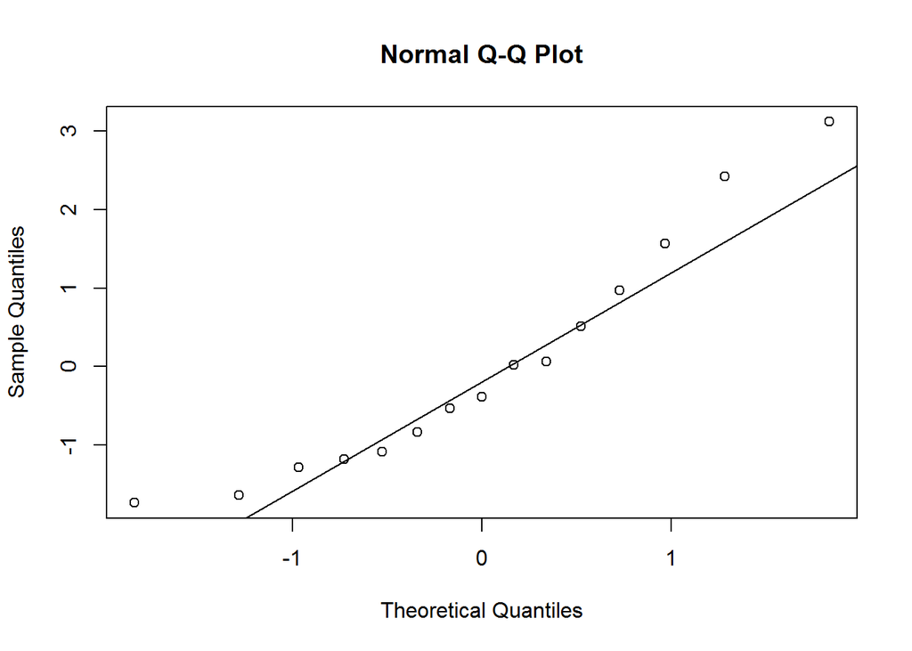

```r
qqnorm(fit1$residuals) ; qqline(fit1$residuals)
```

검정결과, p-value의 값이 0.1866으로 유의수준 0.05보다 크다. 따라서 정규성을 만족하는 것으로 볼 수 있다.

#### 2)) 선형성, 등분산성

여기에서는 패키지 gvlma에 있는 함수 gvlma를 이용해 검정해보도록 하겠다. 실행결과에서 Global test는 선형성에 대한 검정이고 Heteroscedasticity는 등분산성에 대한 검정이다.

```r
library(gvlma)
gvmodel1 <- gvlma(fit1)
summary(gvmodel1)
```

```
##
## Call:
## lm(formula = weight ~ height, data = women)
##
## Residuals:
##     Min      1Q  Median      3Q     Max
## -1.7333 -1.1333 -0.3833  0.7417  3.1167
##
## Coefficients:
##              Estimate Std. Error t value Pr(>|t|)
## (Intercept) -87.51667    5.93694  -14.74 1.71e-09 ***
## height        3.45000    0.09114   37.85 1.09e-14 ***
## ---
## Signif. codes:  0 '***' 0.001 '**' 0.01 '*' 0.05 '.' 0.1 ' ' 1
##
## Residual standard error: 1.525 on 13 degrees of freedom
## Multiple R-squared:  0.991,  Adjusted R-squared:  0.9903
## F-statistic:  1433 on 1 and 13 DF,  p-value: 1.091e-14
##
##
## ASSESSMENT OF THE LINEAR MODEL ASSUMPTIONS
## USING THE GLOBAL TEST ON 4 DEGREES-OF-FREEDOM:
## Level of Significance =  0.05
##
## Call:
##  gvlma(x = fit1)
##
##                      Value   p-value                   Decision
## Global Stat        16.5866 0.0023251 Assumptions NOT satisfied!
## Skewness            1.5577 0.2119999    Assumptions acceptable.
## Kurtosis            0.1019 0.7496131    Assumptions acceptable.
## Link Function      14.1218 0.0001713 Assumptions NOT satisfied!
## Heteroscedasticity  0.8052 0.3695398    Assumptions acceptable.
```

검정결과, 선형성(Global test)에 대한 p-value는 약 0.0023으로 유의수준 0.05보다 작고, 등분산성(Heteroscedasticity)에 대한 p-value는 0.3695으로 유의수준 0.05보다 크다. 따라서 선형성은 만족하지 못하고 등분산성은 만족한다고 볼 수 있다.

#### 3)) 독립성

독립성 검정에는 보통 Durbin-Watson 검정법을 사용하게 되며, 다음과 같은 기준으로 독립성을 판단한다. DW statistic == 2 –> 독립 (row==0) DW statistic == 0 –> 양의 자기상관 (row==1) DW statistic == 4 –> 음의 자기상관 (row==-1)

```r
library(car)
durbinWatsonTest(fit1)
```

```
##  lag Autocorrelation D-W Statistic p-value
##    1        0.585079     0.3153804       0
##  Alternative hypothesis: rho != 0
```

검정결과, p-value의 값이 매우 작다. 따라서 독립성은 만족한다고 볼 수 없다.

결과적으로, 모형 fit1은 회귀모형의 기본가정을 만족하지 못한다. 다만, 키와 몸무게에 대한 산점도와 fit1에 대한 4가지 그래프를 통해 선형관계가 아닌 2차식과 관련한 관계가 있다고 판단되므로 2차식 회귀모형 fit2를 구축해보겠다.

### 3) Polynomial regression

```r
(fit2 <- lm(weight~height+I(height^2),data=women))
```

```
##
## Call:
## lm(formula = weight ~ height + I(height^2), data = women)
##
## Coefficients:
## (Intercept)       height  I(height^2)
##   261.87818     -7.34832      0.08306
```

```r
summary(fit2)
```

```
##
## Call:
## lm(formula = weight ~ height + I(height^2), data = women)
##
## Residuals:
##      Min       1Q   Median       3Q      Max
## -0.50941 -0.29611 -0.00941  0.28615  0.59706
##
## Coefficients:
##              Estimate Std. Error t value Pr(>|t|)
## (Intercept) 261.87818   25.19677  10.393 2.36e-07 ***
## height       -7.34832    0.77769  -9.449 6.58e-07 ***
## I(height^2)   0.08306    0.00598  13.891 9.32e-09 ***
## ---
## Signif. codes:  0 '***' 0.001 '**' 0.01 '*' 0.05 '.' 0.1 ' ' 1
##
## Residual standard error: 0.3841 on 12 degrees of freedom
## Multiple R-squared:  0.9995, Adjusted R-squared:  0.9994
## F-statistic: 1.139e+04 on 2 and 12 DF,  p-value: < 2.2e-16
```

ANOVA table에 의하면 모형 fit2는 상당히 유의하다고 보여진다. 이에 대한 회귀식은 다음과 같이 나타낼 수 있다.  
weight.hat = 261.87818 - 7.34832 * height + 0.08306 * height^2  
다만, 독립변수에 있는 1차항과 2차항은 동일한 변수를 사용하였으므로 다중공선성이 의심가는 상황이다. 이에 따라 분산팽창계수(variance inflation factor, VIF)를 구해보도록 한다.

```r
require(car)
vif(fit2)
```

```
##      height I(height^2)
##    1148.059    1148.059
```

```r
vif(fit2)>10
```

```
##      height I(height^2)
##        TRUE        TRUE
```

분석결과, 분산팽창계수가 모두 10보다 크므로 다중공선성이 존재한다고 볼 수 있다. 이러한 문제점을 보완하기 위해 데이터를 표준화시킨 다음 모형 fit3을 구축해보고 이에 대한 분산팽창계수를 살펴보도록 한다.

```r
women1 <- as.data.frame(scale(women))
(fit3 <- lm(weight~height+I(height^2),data=women1))
```

```
##
## Call:
## lm(formula = weight ~ height + I(height^2), data = women1)
##
## Coefficients:
## (Intercept)       height  I(height^2)
##     -0.1000       0.9955       0.1072
```

```r
summary(fit3)
```

```
##
## Call:
## lm(formula = weight ~ height + I(height^2), data = women1)
##
## Residuals:
##       Min        1Q    Median        3Q       Max
## -0.032868 -0.019105 -0.000607  0.018463  0.038523
##
## Coefficients:
##              Estimate Std. Error t value Pr(>|t|)
## (Intercept) -0.100042   0.009634  -10.38 2.38e-07 ***
## height       0.995495   0.006623  150.31  < 2e-16 ***
## I(height^2)  0.107188   0.007716   13.89 9.32e-09 ***
## ---
## Signif. codes:  0 '***' 0.001 '**' 0.01 '*' 0.05 '.' 0.1 ' ' 1
##
## Residual standard error: 0.02478 on 12 degrees of freedom
## Multiple R-squared:  0.9995, Adjusted R-squared:  0.9994
## F-statistic: 1.139e+04 on 2 and 12 DF,  p-value: < 2.2e-16
```

```r
require(car)
vif(fit3)
```

```
##      height I(height^2)
##           1           1
```

```r
vif(fit3)>10
```

```
##      height I(height^2)
##       FALSE       FALSE
```

분석결과, 분산팽창계수가 10 미만으로 줄어든 것을 확인할 수 있고, 이에 따라 다중공선성 문제를 어느정도 보완했다고 볼 수 있다.

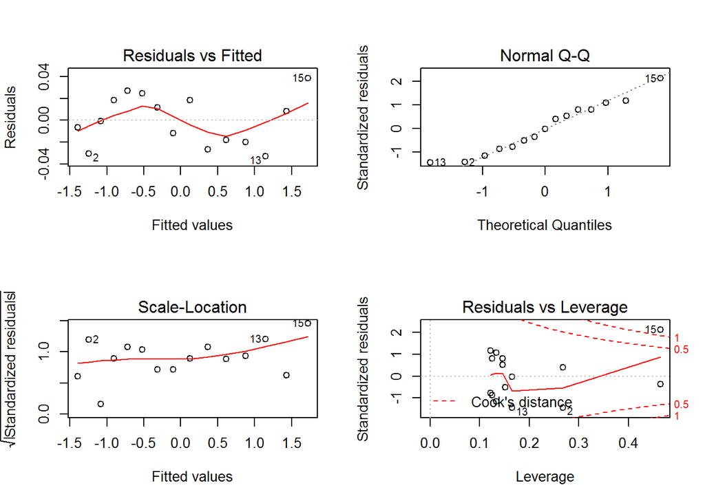

```r
par(mfrow=c(2,2))
plot(fit3)
```

```r
par(mfrow=c(1,1))
shapiro.test(fit3$residuals)
```

```
##
##  Shapiro-Wilk normality test
##
## data:  fit3$residuals
## W = 0.94881, p-value = 0.506
```

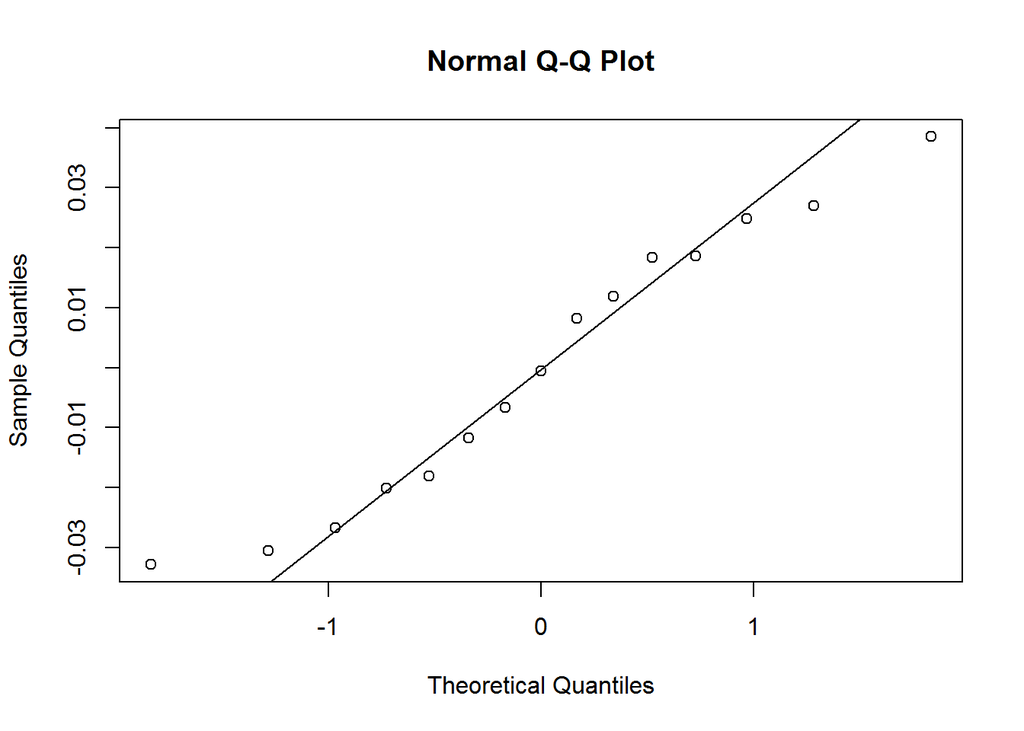

```r
qqnorm(fit3$residuals) ; qqline(fit3$residuals)
```

```r
library(gvlma)
gvmodel3 <- gvlma(fit3)
summary(gvmodel3)
```

```
##
## Call:
## lm(formula = weight ~ height + I(height^2), data = women1)
##
## Residuals:
##       Min        1Q    Median        3Q       Max
## -0.032868 -0.019105 -0.000607  0.018463  0.038523
##
## Coefficients:
##              Estimate Std. Error t value Pr(>|t|)
## (Intercept) -0.100042   0.009634  -10.38 2.38e-07 ***
## height       0.995495   0.006623  150.31  < 2e-16 ***
## I(height^2)  0.107188   0.007716   13.89 9.32e-09 ***
## ---
## Signif. codes:  0 '***' 0.001 '**' 0.01 '*' 0.05 '.' 0.1 ' ' 1
##
## Residual standard error: 0.02478 on 12 degrees of freedom
## Multiple R-squared:  0.9995, Adjusted R-squared:  0.9994
## F-statistic: 1.139e+04 on 2 and 12 DF,  p-value: < 2.2e-16
##
##
## ASSESSMENT OF THE LINEAR MODEL ASSUMPTIONS
## USING THE GLOBAL TEST ON 4 DEGREES-OF-FREEDOM:
## Level of Significance =  0.05
##
## Call:
##  gvlma(x = fit3)
##
##                        Value  p-value                   Decision
## Global Stat        10.858254 0.028204 Assumptions NOT satisfied!
## Skewness            0.005991 0.938306    Assumptions acceptable.
## Kurtosis            1.027270 0.310801    Assumptions acceptable.
## Link Function       9.128078 0.002517 Assumptions NOT satisfied!
## Heteroscedasticity  0.696916 0.403822    Assumptions acceptable.
```

```r
library(car)
durbinWatsonTest(fit3)
```

```
##  lag Autocorrelation D-W Statistic p-value
##    1       0.3242888      1.144043   0.012
##  Alternative hypothesis: rho != 0
```

다만, 아직도 선형성과 독립성에 대한 가정은 만족하지 못하는 상황이다. 따라서 좀 더 합리적인 모형에 대한 연구는 변수변환이나 비모수 회귀 등을 이용하여 더 진행해봐야 할 것 같다.